# Direct Marketing campaign analysis

By Verra Lucas

December 13, 2016

# Explarotory Data Analysis on direct marketing campaign from Portuguese Bank

### Abstract :

This exercice reflects what we have learned on Udacity’s Data Analyst NanoDegree, Exploratory Data analysis lesson. The data is related with direct marketing campaigns (phone calls) of a Portuguese banking institution. The classification goal is to predict if the client will subscribe a term deposit (variable y)

The data set is provided by the [UC Irvine Machine Learning Repository](http://archive.ics.uci.edu/ml/datasets/Bank+Marketing) [Moro et al., 2014] S. Moro, P. Cortez and P. Rita. A Data-Driven Approach to Predict the Success of Bank Telemarketing. Decision Support Systems, Elsevier, 62:22-31, June 2014

### Univariate Plots Section

In this section, we will will explore many variables and their distributions. The objective is to have a general understanding of the data presented in the dataset.

#### Length & Structure

```
## [1] 41188
```

The data is divided in 21 variables

```
##  [1] "age"            "job"            "marital"        "education"
##  [5] "default"        "housing"        "loan"           "contact"
##  [9] "month"          "day_of_week"    "duration"       "campaign"
## [13] "pdays"          "previous"       "poutcome"       "emp.var.rate"
## [17] "cons.price.idx" "cons.conf.idx"  "euribor3m"      "nr.employed"
## [21] "y"
```

> Input variables: # bank client data:  
> 1 - age (numeric)  
> 2 - job : type of job (categorical: “admin.”,“blue-collar”,“entrepreneur”,“housemaid”,“management”,“retired”,“self-employed”,“services”,“student”,“technician”,“unemployed”,“unknown”) 3 - marital : marital status (categorical: “divorced”,“married”,“single”,“unknown”; note: “divorced” means divorced or widowed)  
> 4 - education (categorical: “basic.4y”,“basic.6y”,“basic.9y”,“high.school”,“illiterate”,“professional.course”,“university.degree”,“unknown”)  
> 5 - default: has credit in default? (categorical: “no”,“yes”,“unknown”)  
> 6 - housing: has housing loan? (categorical: “no”,“yes”,“unknown”)  
> 7 - loan: has personal loan? (categorical: “no”,“yes”,“unknown”)  
> # related with the last contact of the current campaign:  
> 8 - contact: contact communication type (categorical: “cellular”,“telephone”)  
> 9 - month: last contact month of year (categorical: “jan”, “feb”, “mar”, …, “nov”, “dec”)  
> 10 - day_of_week: last contact day of the week (categorical: “mon”,“tue”,“wed”,“thu”,“fri”)  
> 11 - duration: last contact duration, in seconds (numeric). Important note: this attribute highly affects the output target (e.g., if duration=0 then y=“no”). Yet, the duration is not known before a call is performed. Also, after the end of the call y is obviously known. Thus, this input should only be included for benchmark purposes and should be discarded if the intention is to have a realistic predictive model.  
> # other attributes:  
> 12 - campaign: number of contacts performed during this campaign and for this client (numeric, includes last contact)  
> 13 - pdays: number of days that passed by after the client was last contacted from a previous campaign (numeric; 999 means client was not previously contacted)  
> 14 - previous: number of contacts performed before this campaign and for this client (numeric)  
> 15 - poutcome: outcome of the previous marketing campaign (categorical: “failure”,“nonexistent”,“success”)  
> # social and economic context attributes  
> 16 - emp.var.rate: employment variation rate - quarterly indicator (numeric)  
> 17 - cons.price.idx: consumer price index - monthly indicator (numeric)  
> 18 - cons.conf.idx: consumer confidence index - monthly indicator (numeric)  
> 19 - euribor3m: euribor 3 month rate - daily indicator (numeric)  
> 20 - nr.employed: number of employees - quarterly indicator (numeric)  
> Output variable (desired target):  
> 21 - y - has the client subscribed a term deposit? (binary: “yes”,“no”)

Data is grouped in 4 ‘types of data’ :

1. Client Data - Demographic [age - education]
2. Client Data - Banking [defaut - loan]
3. Campaign data - [contact - poutcome]
4. Macro social and economic portuguese context [emp.var.rate - nr.employed]

The last one, named ‘y’ represent the success/failure of the marketing campaign.

> “The client has purchased the service marketed”

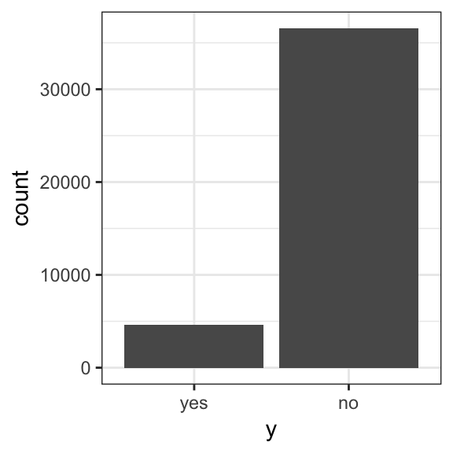

#### Client Data

We can quickly see that the Client data aspect of the dataset is predominantly based on factor type of variables, except for the ‘age’ varible.

For each variable displayed, the count and proportions of the total are represented next to each other.

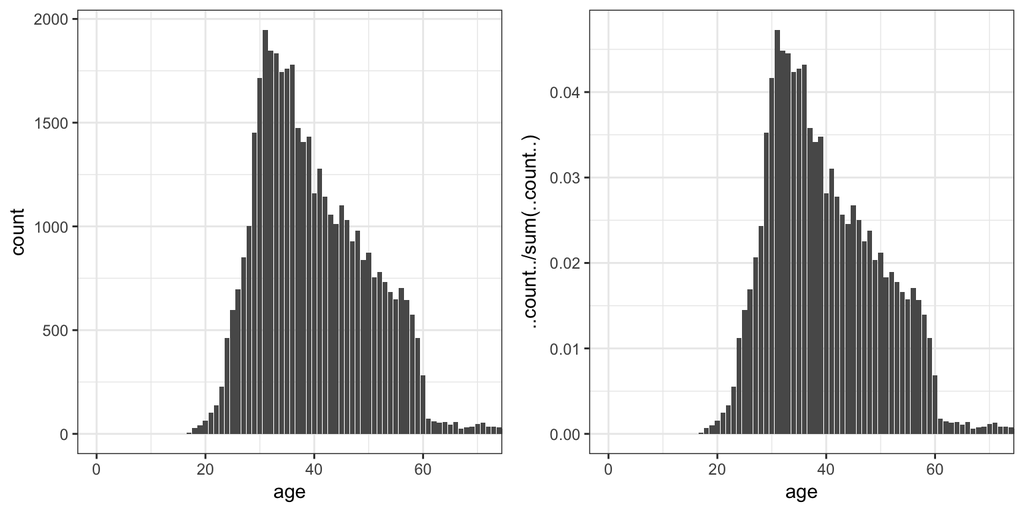

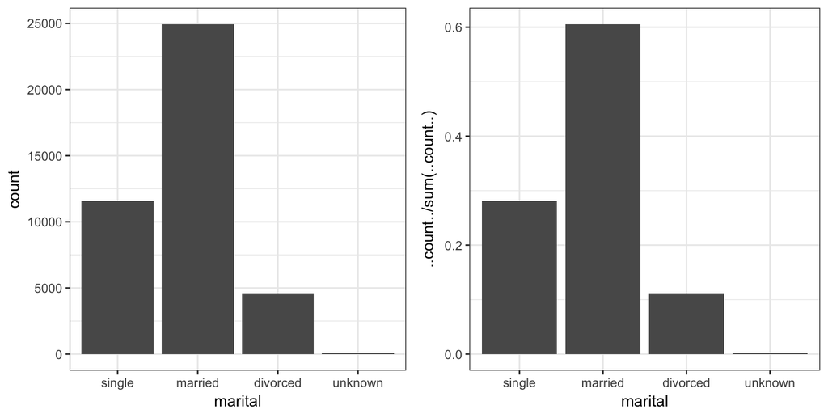

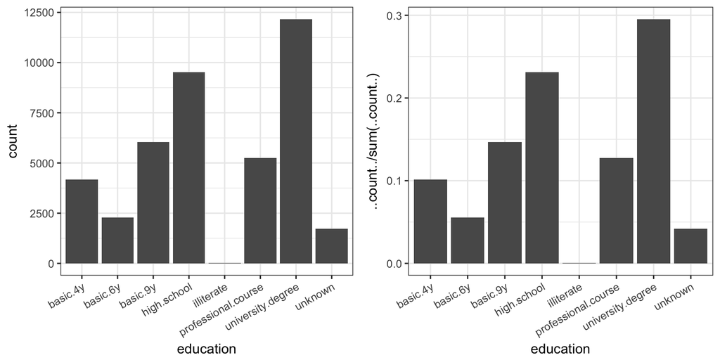

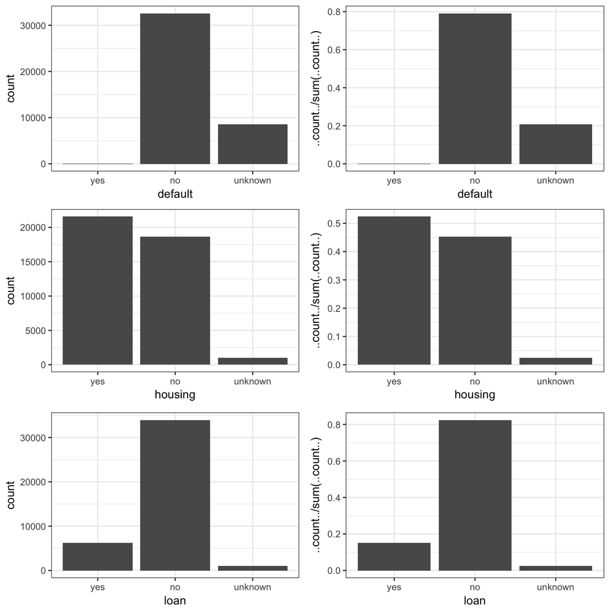

#### Campaign Data

Variables in this section are categorical but also numerical.

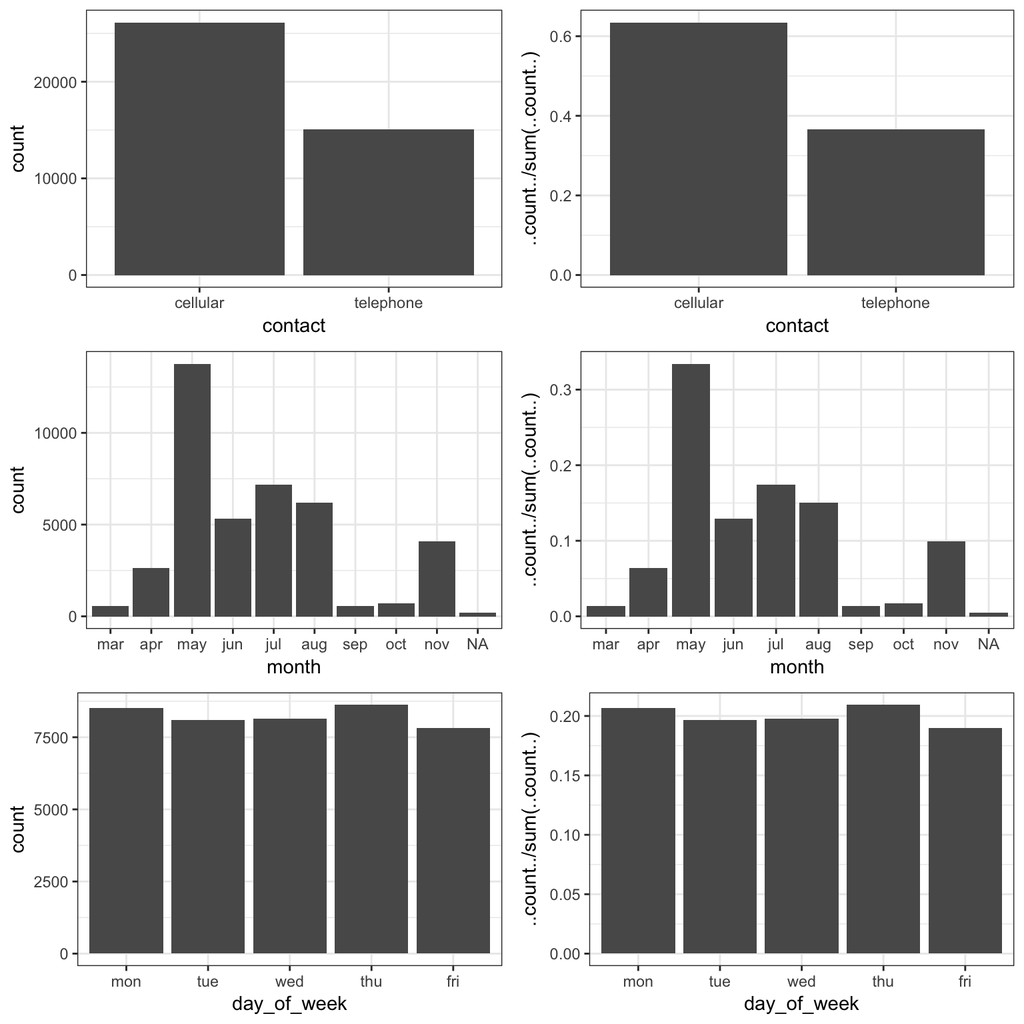

The following plot represent the campaign variable, described as

> number of contacts performed during this campaign and for this client (numeric, includes last contact)

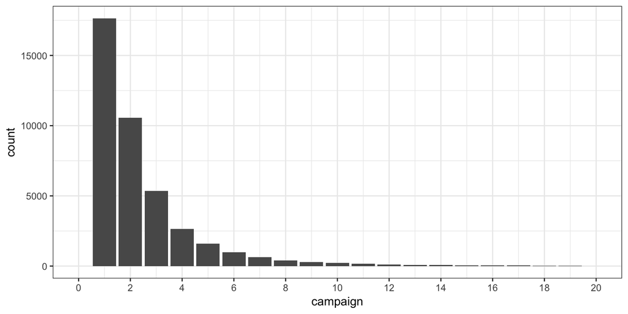

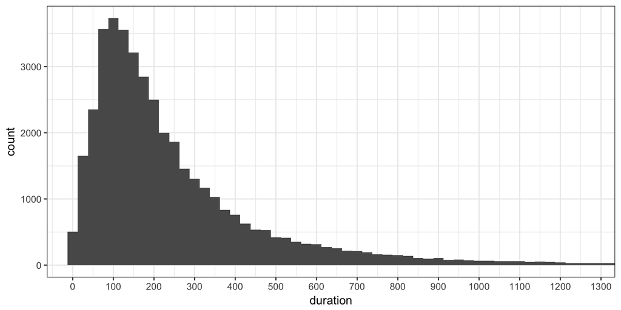

Both distribution are heavyly skewed towards the low values

#### Macro social and economic portuguese context data

The histograms show that the distribution for those variables are not ‘conventional’

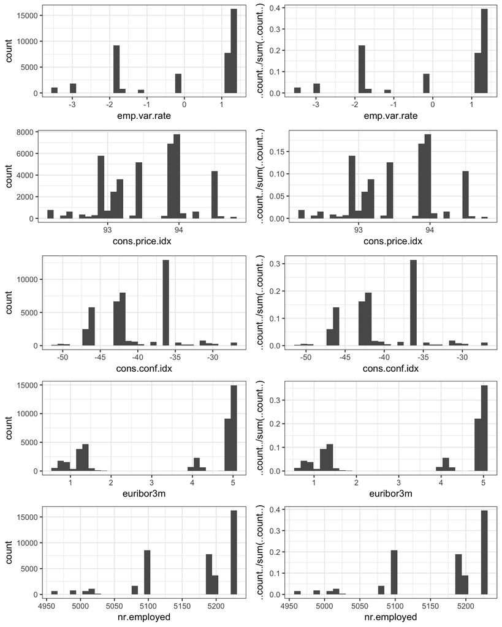

```
## 'data.frame':    41188 obs. of  22 variables:
##  $ age           : int  56 57 37 40 56 45 59 41 24 25 ...
##  $ job           : Factor w/ 12 levels "admin.","blue-collar",..: 4 8 8 1 8 8 1 2 10 8 ...
##  $ marital       : Ord.factor w/ 4 levels "single"<"married"<..: 2 2 2 2 2 2 2 2 1 1 ...
##  $ education     : Factor w/ 8 levels "basic.4y","basic.6y",..: 1 4 4 2 4 3 6 8 6 4 ...
##  $ default       : Ord.factor w/ 3 levels "yes"<"no"<"unknown": 2 3 2 2 2 3 2 3 2 2 ...
##  $ housing       : Ord.factor w/ 3 levels "yes"<"no"<"unknown": 2 2 1 2 2 2 2 2 1 1 ...
##  $ loan          : Ord.factor w/ 3 levels "yes"<"no"<"unknown": 2 2 2 2 1 2 2 2 2 2 ...
##  $ contact       : Factor w/ 2 levels "cellular","telephone": 2 2 2 2 2 2 2 2 2 2 ...
##  $ month         : Ord.factor w/ 10 levels "mar"<"apr"<"may"<..: 3 3 3 3 3 3 3 3 3 3 ...
##  $ day_of_week   : Ord.factor w/ 5 levels "mon"<"tue"<"wed"<..: 1 1 1 1 1 1 1 1 1 1 ...
##  $ duration      : int  261 149 226 151 307 198 139 217 380 50 ...
##  $ campaign      : int  1 1 1 1 1 1 1 1 1 1 ...
##  $ pdays         : int  999 999 999 999 999 999 999 999 999 999 ...
##  $ previous      : int  0 0 0 0 0 0 0 0 0 0 ...
##  $ poutcome      : Factor w/ 3 levels "failure","nonexistent",..: 2 2 2 2 2 2 2 2 2 2 ...
##  $ emp.var.rate  : num  1.1 1.1 1.1 1.1 1.1 1.1 1.1 1.1 1.1 1.1 ...
##  $ cons.price.idx: num  94 94 94 94 94 ...
##  $ cons.conf.idx : num  -36.4 -36.4 -36.4 -36.4 -36.4 -36.4 -36.4 -36.4 -36.4 -36.4 ...
##  $ euribor3m     : num  4.86 4.86 4.86 4.86 4.86 ...
##  $ nr.employed   : num  5191 5191 5191 5191 5191 ...
##  $ y             : Ord.factor w/ 2 levels "yes"<"no": 2 2 2 2 2 2 2 2 2 2 ...
##  $ hasloan       : Ord.factor w/ 2 levels "yes"<"no/unknown": 2 2 1 2 1 2 2 2 1 1 ...
```

```
##       age                 job            marital
##  Min.   :17.00   admin.     :10422   single  :11568
##  1st Qu.:32.00   blue-collar: 9254   married :24928
##  Median :38.00   technician : 6743   divorced: 4612
##  Mean   :40.02   services   : 3969   unknown :   80
##  3rd Qu.:47.00   management : 2924
##  Max.   :98.00   retired    : 1720
##                  (Other)    : 6156
##                education        default         housing
##  university.degree  :12168   yes    :    3   yes    :21576
##  high.school        : 9515   no     :32588   no     :18622
##  basic.9y           : 6045   unknown: 8597   unknown:  990
##  professional.course: 5243
##  basic.4y           : 4176
##  basic.6y           : 2292
##  (Other)            : 1749
##       loan            contact          month       day_of_week
##  yes    : 6248   cellular :26144   may    :13769   mon:8514
##  no     :33950   telephone:15044   jul    : 7174   tue:8090
##  unknown:  990                     aug    : 6178   wed:8134
##                                    jun    : 5318   thu:8623
##                                    nov    : 4101   fri:7827
##                                    (Other): 4466
##                                    NA's   :  182
##     duration         campaign          pdays          previous
##  Min.   :   0.0   Min.   : 1.000   Min.   :  0.0   Min.   :0.000
##  1st Qu.: 102.0   1st Qu.: 1.000   1st Qu.:999.0   1st Qu.:0.000
##  Median : 180.0   Median : 2.000   Median :999.0   Median :0.000
##  Mean   : 258.3   Mean   : 2.568   Mean   :962.5   Mean   :0.173
##  3rd Qu.: 319.0   3rd Qu.: 3.000   3rd Qu.:999.0   3rd Qu.:0.000
##  Max.   :4918.0   Max.   :56.000   Max.   :999.0   Max.   :7.000
##
##         poutcome      emp.var.rate      cons.price.idx  cons.conf.idx
##  failure    : 4252   Min.   :-3.40000   Min.   :92.20   Min.   :-50.8
##  nonexistent:35563   1st Qu.:-1.80000   1st Qu.:93.08   1st Qu.:-42.7
##  success    : 1373   Median : 1.10000   Median :93.75   Median :-41.8
##                      Mean   : 0.08189   Mean   :93.58   Mean   :-40.5
##                      3rd Qu.: 1.40000   3rd Qu.:93.99   3rd Qu.:-36.4
##                      Max.   : 1.40000   Max.   :94.77   Max.   :-26.9
##
##    euribor3m      nr.employed     y               hasloan
##  Min.   :0.634   Min.   :4964   yes: 4640   yes       :24133
##  1st Qu.:1.344   1st Qu.:5099   no :36548   no/unknown:17055
##  Median :4.857   Median :5191
##  Mean   :3.621   Mean   :5167
##  3rd Qu.:4.961   3rd Qu.:5228
##  Max.   :5.045   Max.   :5228
##
```

### What is/are the main feature(s) of interest in your dataset?

The main feature of this dataset is that it clearly represents the information produced during a business process : A direct marketing campaign. Business driven, we can perceived a sucess/failure variable that will be key to anaylse the other variables.

### What other features in the dataset do you think will help support your investigation into your feature(s) of interest?

Besides the sucess/failure variable, we are provided with 3 blocks of data :

1. Client data
2. Campaign data
3. Macro socio-economic data

We will investigate how success variable is related to those blocks, and if one is more significant in the correlation with a sucess event

### Did you create any new variables from existing variables in the dataset?

Yes, We created a new variable that ‘merges’ the information contained in housing and loan variables. The objective is to have one variable that aggregate the binari condition of having a loan.  
The new variable is called ‘hasloan’. Value ‘yes’ if housing == ‘yes’ OR loan == ‘yes’

### Of the features you investigated, were there any unusual distributions? Did you perform any operations on the data to tidy, adjust, or change the form of the data? If so, why did you do this?

Yes, as seen previoulsy, the Macro socio-economic block of data has a rather unusual distribution. I did not perform any operation on these variables as I have no experience dealing with this type of data. Nothing seems to point to a corrupted/flawed data input.

Regarding the duration variable, we can apply the log transformation in order to make it as normal as possible. Althought after lots of reading, i still do not understand why i do this

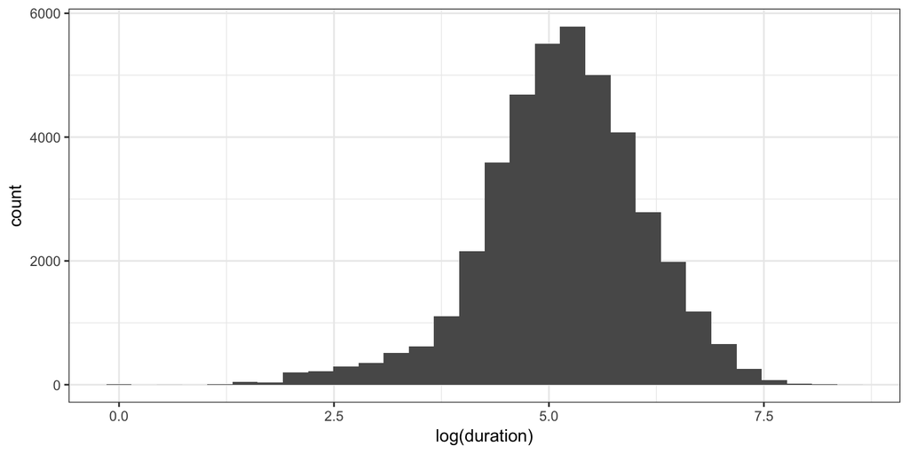

# Bivariate Plots Section

Now that we have a good understanding of each variable of its own, lets start building relationships. Our focus of investigation will trying to understand what variables are signicantly correlated with the **‘y’** variable, indicating sucess in the marketing campaign.

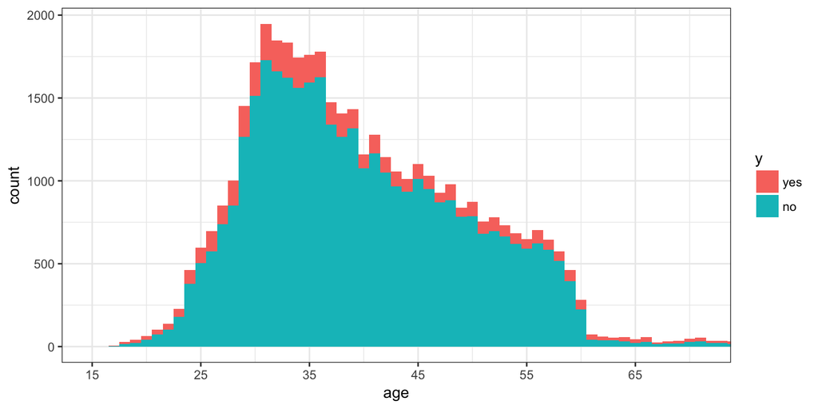

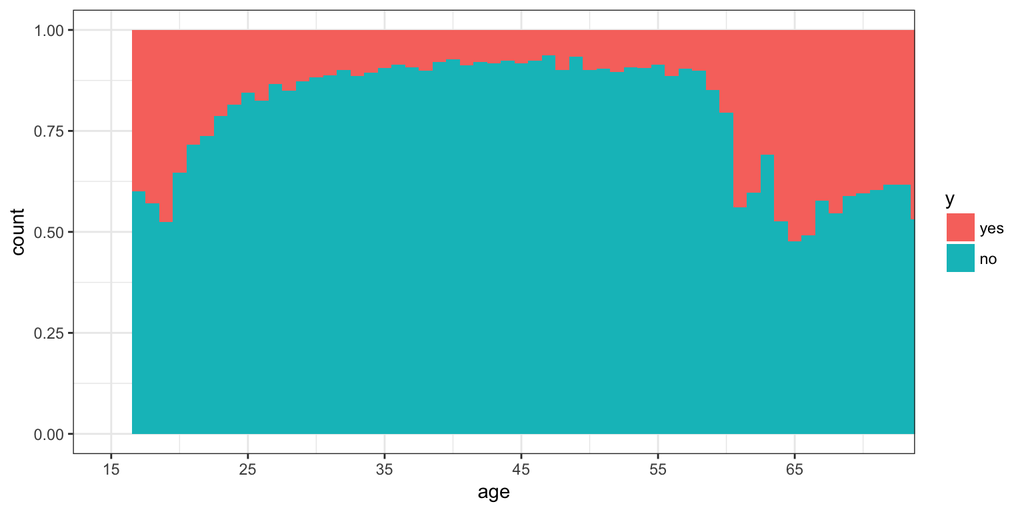

> The more observation in any given bin, the less Y (sucess) proportion

Let’s plot it in a classic boxplot

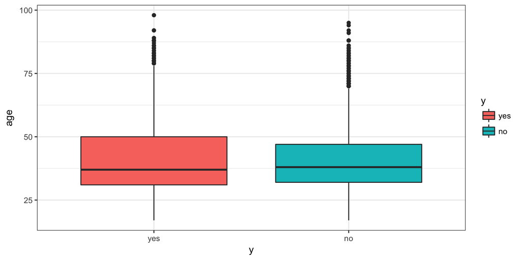

Nothing catch our attention, execpt a larger IQR in the Yes (sucess) observation. Lets make use of the library GGally to plot the relations between variables, trying to always relate to the output variable Y.

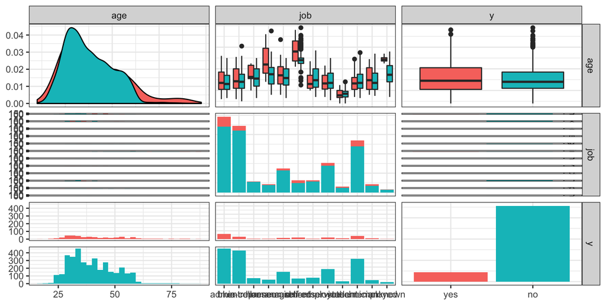

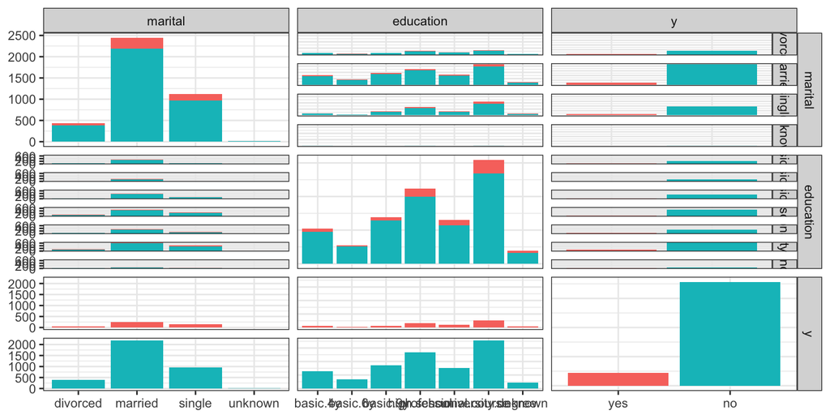

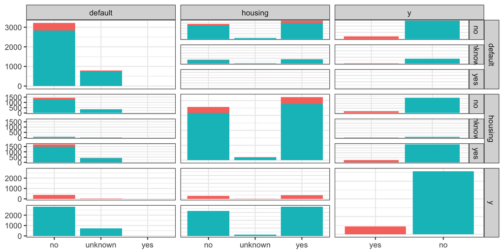

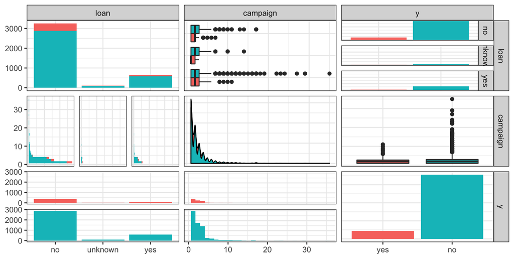

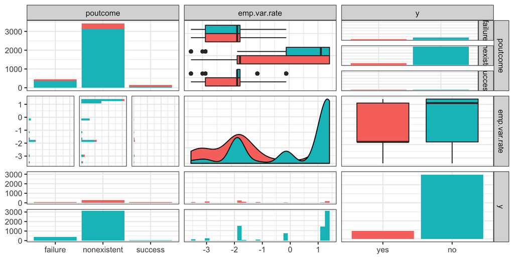

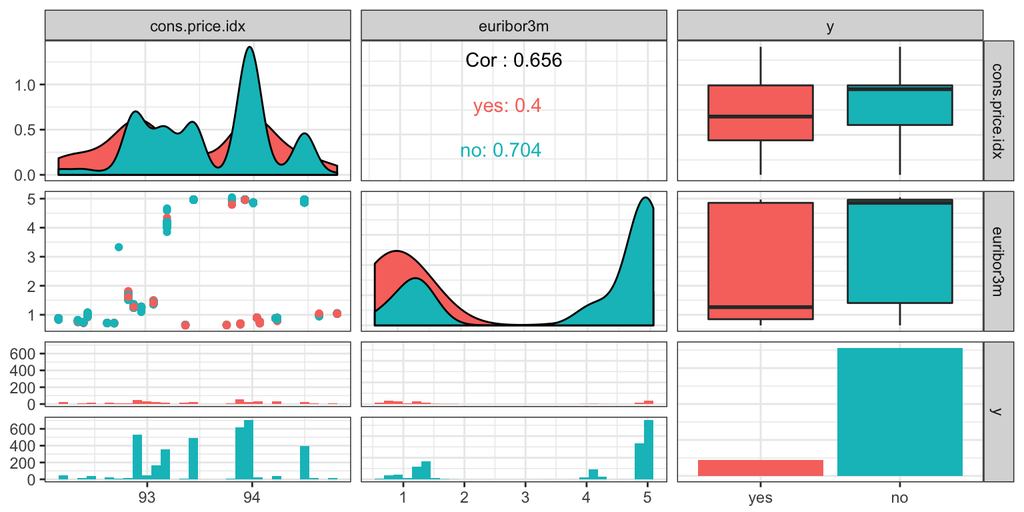

GGpairs is no magic so lets get deeper for the variables that have shown significant differences for the Y(sucess/failure) variable

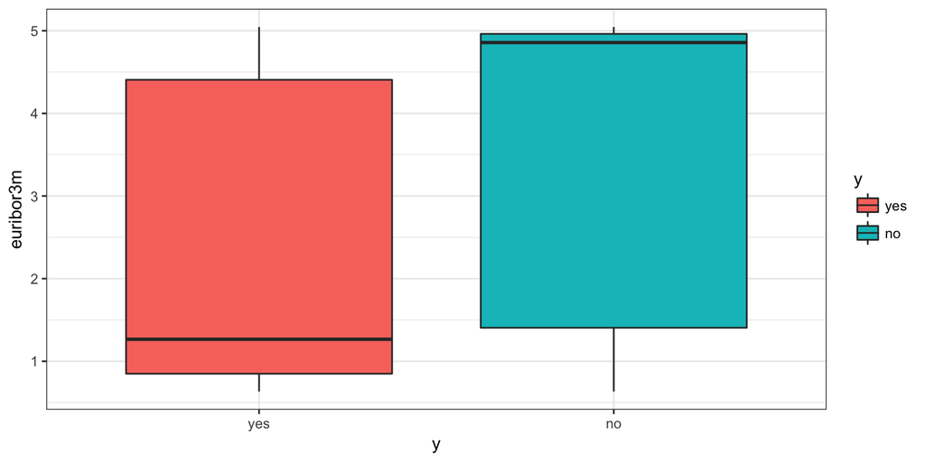

Let’s remember that variable distribution

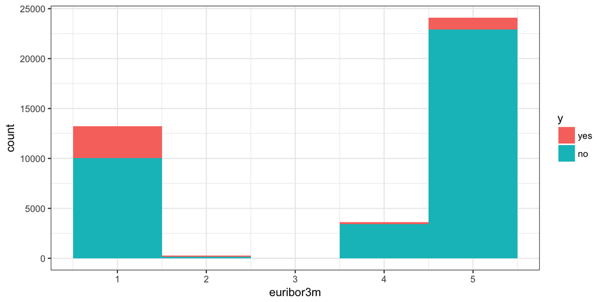

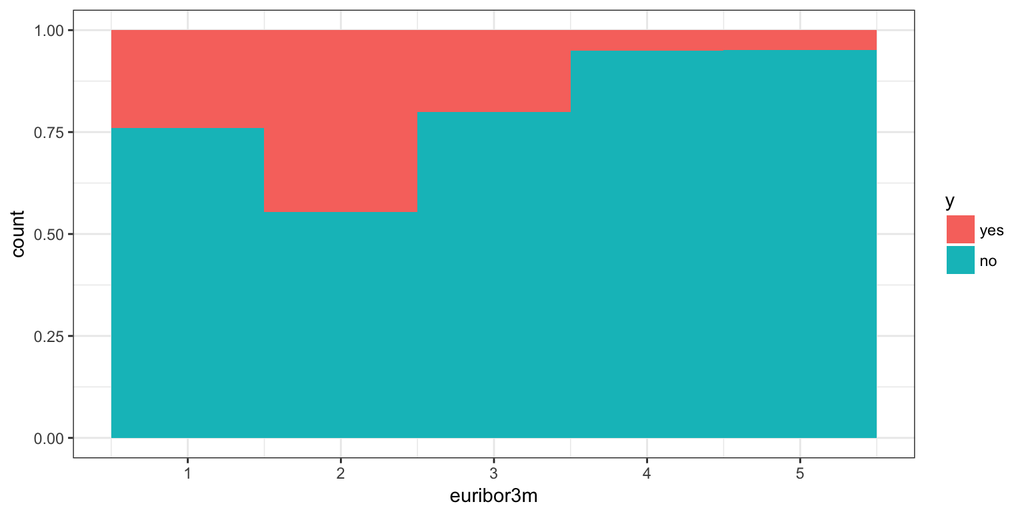

> Why is Euribor important? The Euribor rates are important because these rates provide the basis for the price or interest rate of all kinds of financial products, like interest rate swaps, interest rate futures, saving accounts (see: Euribor and savings) and mortgages. ([link](http://www.euribor-rates.eu/what-is-euribor.asp))